# Tugas Praktikum 1

Luthfia Aiman Hanin_G1401231064

2025-09-01

```r
library("forecast")
```

```r
library("graphics")
library("TTR")
library("TSA")
library(dplyr)
library(lubridate)
library(tidyr)
#Import data xlsx
library(rio)
gold <- import("https://github.com/shafifaris/MPDW/raw/main/Pertemuan%202/Gold%20Price.xlsx")
gold
```

```
##           Date Price
## 1   2023-01-25 56865
## 2   2023-01-27 56789
## 3   2023-01-30 56754
## 4   2023-01-31 56864
## 5   2023-02-01 57599
## 6   2023-02-02 57710
## 7   2023-02-03 57424
## 8   2023-02-06 56926
## 9   2023-02-07 57175
## 10  2023-02-08 57128
## 11  2023-02-09 56797
## 12  2023-02-10 56711
## 13  2023-02-13 56486
## 14  2023-02-14 56679
```

[output cut: 486 more lines]

# Eksplorasi Data

```r
View(gold)
str(gold)
```

```
## 'data.frame':    500 obs. of  2 variables:
##  $ Date : POSIXct, format: "2023-01-25" "2023-01-27" ...
##  $ Price: num  56865 56789 56754 56864 57599 ...
```

```r
dim(gold)
```

```
## [1] 500   2
```

```r
data <- gold[301:400,]
data
```

```
##           Date Price
## 301 2024-03-27 66295
## 302 2024-03-28 67592
## 303 2024-04-01 68263
## 304 2024-04-02 68802
## 305 2024-04-03 69725
## 306 2024-04-04 69612
## 307 2024-04-05 70701
## 308 2024-04-08 70607
## 309 2024-04-09 71130
## 310 2024-04-10 71127
## 311 2024-04-11 71514
## 312 2024-04-12 71857
## 313 2024-04-15 72329
## 314 2024-04-16 73109
```

[output cut: 86 more lines]

```r
data$Date <- as.Date(data$Date)
all_dates <- seq(min(data$Date), max(data$Date), by = "day")
missing_dates <- setdiff(all_dates, data$Date)
missing_dates
```

```
##  [1] 19811 19812 19813 19819 19820 19826 19827 19833 19834 19840 19841 19847
## [13] 19848 19854 19855 19861 19862 19868 19869 19875 19876 19882 19883 19889
## [25] 19890 19896 19897 19903 19904 19910 19911 19917 19918 19924 19925 19931
## [37] 19932 19938 19939 19945 19946
```

```r
#Mengubah data agar terbaca sebagai time series
data.ts <- ts(data$Price)
data.ts
```

```
## Time Series:
## Start = 1
## End = 100
## Frequency = 1
##   [1] 66295 67592 68263 68802 69725 69612 70701 70607 71130 71127 71514 71857
##  [13] 72329 73109 72695 73016 73246 71936 71590 71692 71725 72107 72250 70969
##  [25] 71274 71119 70998 71321 71136 71129 71586 72595 71819 72213 73001 72896
##  [37] 73593 74283 73970 73027 71632 71380 72001 72145 71993 71852 71703 71818
##  [49] 71782 72485 72963 71308 71303 71346 71796 71030 71691 71285 71503 71519
##  [61] 72258 71429 71512 71201 70919 71303 71275 71329 71357 72160 72151 73255
##  [73] 72332 72385 72629 73205 73159 73311 74025 73924 73965 72872 72641 68648
##  [85] 69028 67491 68173 68206 68617 69083 69412 69381 68641 68742 68752 69396
##  [97] 69604 70354 70356 69874
```

```r
#buatkan frekuensi mingguan
gold.ts <- ts(data$Price, frequency = 7)
gold.ts
```

```
## Time Series:
## Start = c(1, 1)
## End = c(15, 2)
## Frequency = 7
##   [1] 66295 67592 68263 68802 69725 69612 70701 70607 71130 71127 71514 71857
##  [13] 72329 73109 72695 73016 73246 71936 71590 71692 71725 72107 72250 70969
##  [25] 71274 71119 70998 71321 71136 71129 71586 72595 71819 72213 73001 72896
##  [37] 73593 74283 73970 73027 71632 71380 72001 72145 71993 71852 71703 71818
##  [49] 71782 72485 72963 71308 71303 71346 71796 71030 71691 71285 71503 71519
##  [61] 72258 71429 71512 71201 70919 71303 71275 71329 71357 72160 72151 73255
##  [73] 72332 72385 72629 73205 73159 73311 74025 73924 73965 72872 72641 68648
##  [85] 69028 67491 68173 68206 68617 69083 69412 69381 68641 68742 68752 69396
##  [97] 69604 70354 70356 69874
```

```r
#Menampilkan ringkasan data
summary(gold.ts)
```

```
##    Min. 1st Qu.  Median    Mean 3rd Qu.    Max.
##   66295   70865   71517   71327   72330   74283
```

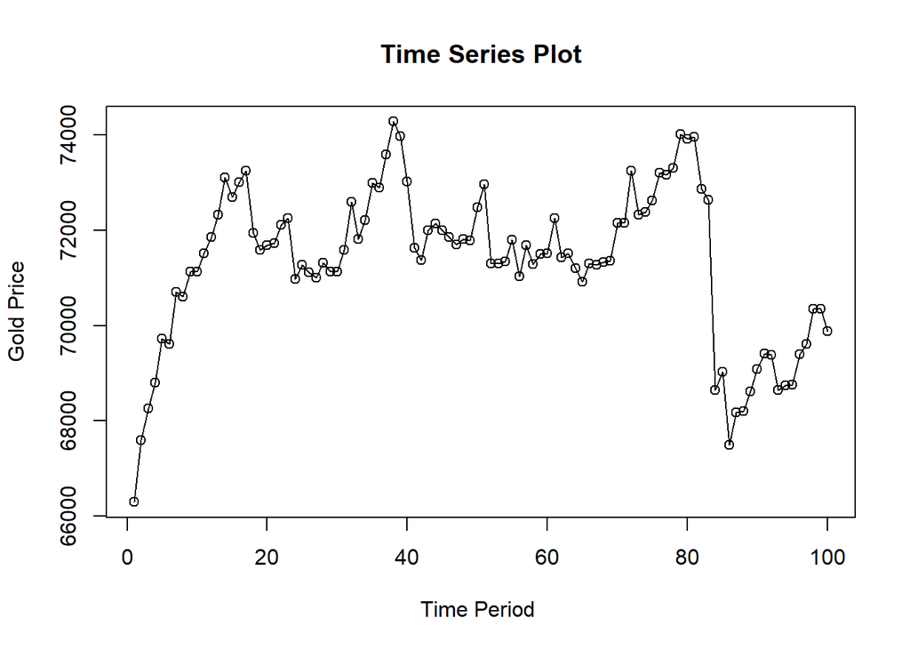

```r
#Membuat plot time series
ts.plot(data.ts, xlab="Time Period ", ylab="Gold Price",
        main = "Time Series Plot")
points(data.ts)
```

# Single Moving Average & Double Moving Average

## Pembagian Data

Pembagian data latih dan data uji dilakukan dengan perbandingan 80% data latih dan 20% data uji.

```r
# hitung jumlah data
n <- nrow(data)

# tentukan batas 80%
n_train <- floor(0.8 * n)

# bagi data
training_ma <- data[1:n_train, ]
testing_ma  <- data[(n_train+1):n, ]

# ubah ke time series
train_ma.ts <- ts(training_ma$Price)
test_ma.ts  <- ts(testing_ma$Price)
```

Eksplorasi data dilakukan pada keseluruhan data, data latih serta data uji menggunakan plot data deret waktu.

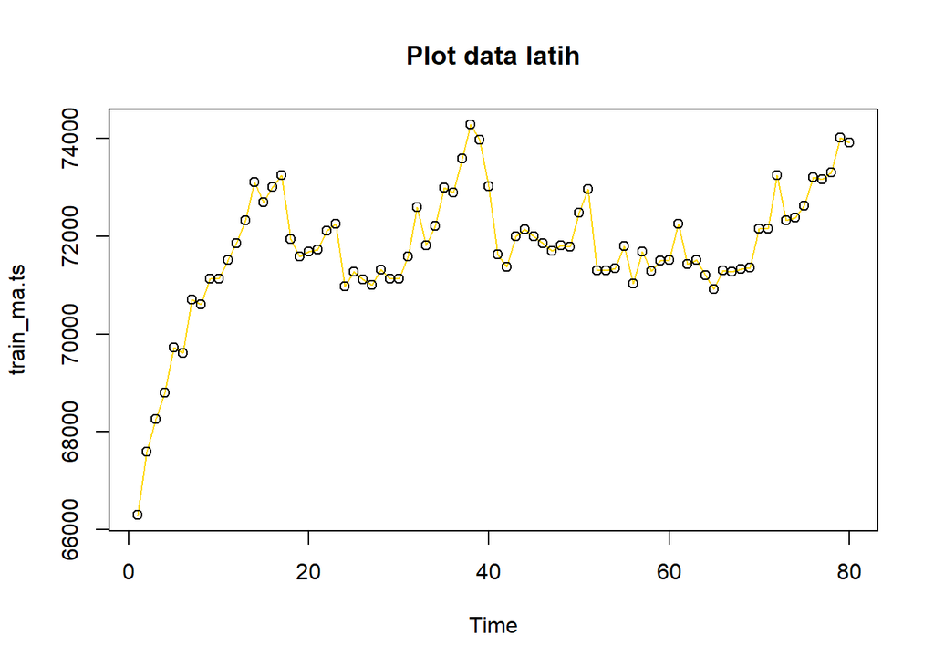

```r
#eksplorasi data latih
library(ggplot2)
plot(train_ma.ts, col="gold",main="Plot data latih")
points(train_ma.ts)
```

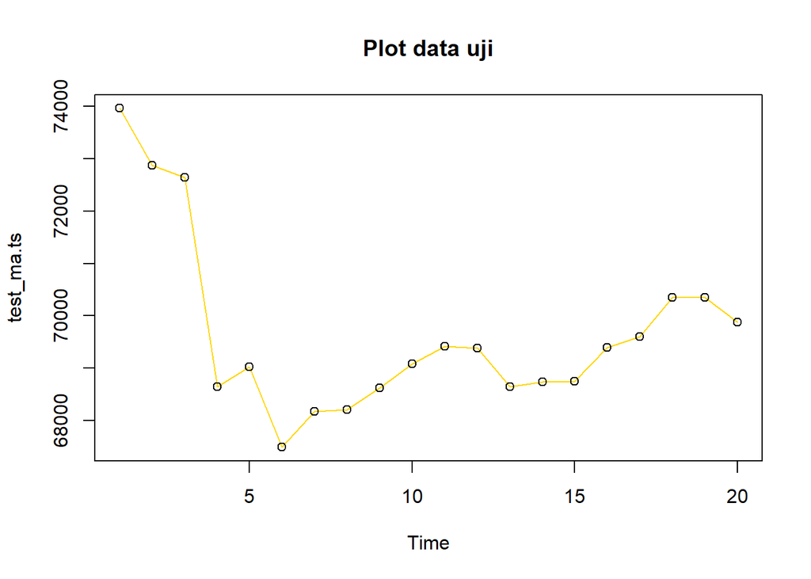

```r
#eksplorasi data uji
plot(test_ma.ts, col="gold",main="Plot data uji")
points(test_ma.ts)
```

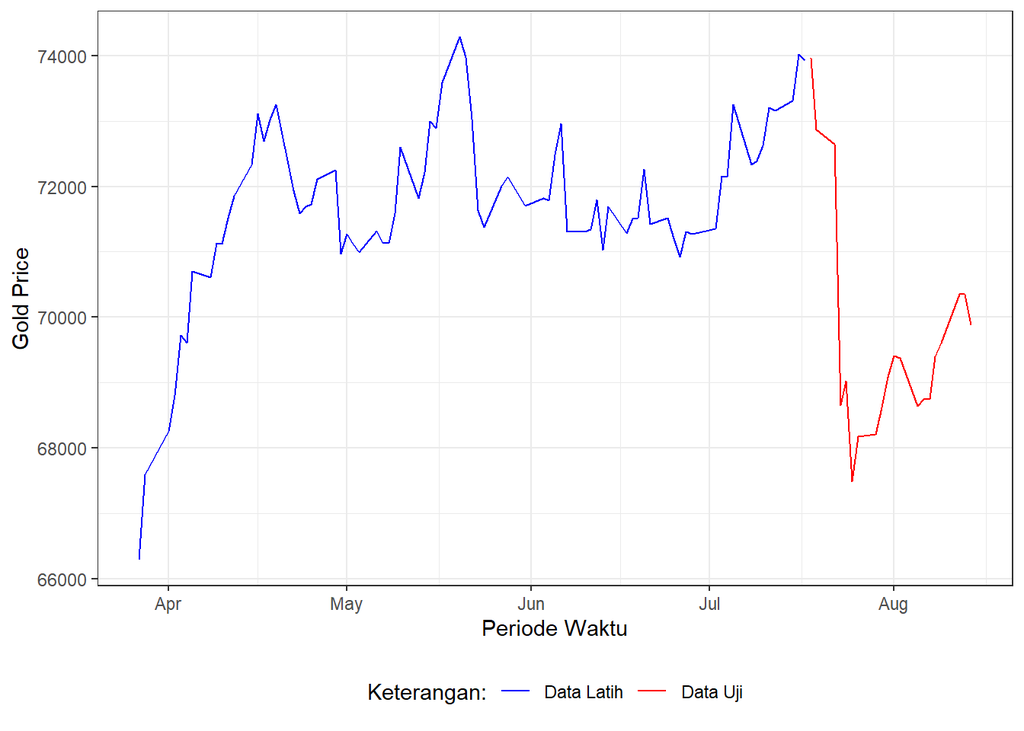

```r
library(ggplot2)
ggplot() +
  geom_line(data = training_ma, aes(x = Date, y = Price, col = "Data Latih")) +
  geom_line(data = testing_ma, aes(x = Date, y = Price, col = "Data Uji")) +
  labs(x = "Periode Waktu", y = "Gold Price", color = "Legend") +
   scale_colour_manual(name="Keterangan:", breaks = c("Data Latih", "Data Uji"),
                      values = c("blue", "red")) +
  theme_bw() + theme(legend.position = "bottom",
                     plot.caption = element_text(hjust=0.5, size=12))
```

## Single Moving Average (SMA)

Pemulusan menggunakan metode SMA dilakukan dengan fungsi `SMA()`. Dalam hal ini akan dilakukan pemulusan dengan parameter `n=4`.

```r
data.sma<-SMA(train_ma.ts, n=4)
data.sma
```

```
## Time Series:
## Start = 1
## End = 80
## Frequency = 1
##  [1]       NA       NA       NA 67738.00 68595.50 69100.50 69710.00 70161.25
##  [9] 70512.50 70891.25 71094.50 71407.00 71706.75 72202.25 72497.50 72787.25
## [17] 73016.50 72723.25 72447.00 72116.00 71735.75 71778.50 71943.50 71762.75
## [25] 71650.00 71403.00 71090.00 71178.00 71143.50 71146.00 71293.00 71611.50
## [33] 71782.25 72053.25 72407.00 72482.25 72925.75 73443.25 73685.50 73718.25
## [41] 73228.00 72502.25 72010.00 71789.50 71879.75 71997.75 71923.25 71841.50
## [49] 71788.75 71947.00 72262.00 72134.50 72014.75 71730.00 71438.25 71368.75
## [57] 71465.75 71450.50 71377.25 71499.50 71641.25 71677.25 71679.50 71600.00
## [65] 71265.25 71233.75 71174.50 71206.50 71316.00 71530.25 71749.25 72230.75
## [73] 72474.50 72530.75 72650.25 72637.75 72844.50 73076.00 73425.00 73604.75
```

Data pemulusan pada periode ke-t selanjutnya digunakan sebagai nilai peramalan pada periode ke t+1 sehingga hasil peramalan 1 periode kedepan adalah sebagai berikut.

```r
data.ramal<-c(NA,data.sma)
data.ramal #forecast 1 periode ke depan
```

```
##  [1]       NA       NA       NA       NA 67738.00 68595.50 69100.50 69710.00
##  [9] 70161.25 70512.50 70891.25 71094.50 71407.00 71706.75 72202.25 72497.50
## [17] 72787.25 73016.50 72723.25 72447.00 72116.00 71735.75 71778.50 71943.50
## [25] 71762.75 71650.00 71403.00 71090.00 71178.00 71143.50 71146.00 71293.00
## [33] 71611.50 71782.25 72053.25 72407.00 72482.25 72925.75 73443.25 73685.50
## [41] 73718.25 73228.00 72502.25 72010.00 71789.50 71879.75 71997.75 71923.25
## [49] 71841.50 71788.75 71947.00 72262.00 72134.50 72014.75 71730.00 71438.25
## [57] 71368.75 71465.75 71450.50 71377.25 71499.50 71641.25 71677.25 71679.50
## [65] 71600.00 71265.25 71233.75 71174.50 71206.50 71316.00 71530.25 71749.25
## [73] 72230.75 72474.50 72530.75 72650.25 72637.75 72844.50 73076.00 73425.00
## [81] 73604.75
```

```r
data.gab<-cbind(
  aktual=c(data.ts),
  pemulusan=c(data.sma,rep(NA,24)),
  ramalan=c(data.ramal,rep(data.ramal[length(data.ramal)],23)))
data.gab #forecast 24 periode ke depan
```

```
##        aktual pemulusan  ramalan
##   [1,]  66295        NA       NA
##   [2,]  67592        NA       NA
##   [3,]  68263        NA       NA
##   [4,]  68802  67738.00       NA
##   [5,]  69725  68595.50 67738.00
##   [6,]  69612  69100.50 68595.50
##   [7,]  70701  69710.00 69100.50
##   [8,]  70607  70161.25 69710.00
##   [9,]  71130  70512.50 70161.25
##  [10,]  71127  70891.25 70512.50
##  [11,]  71514  71094.50 70891.25
##  [12,]  71857  71407.00 71094.50
##  [13,]  72329  71706.75 71407.00
##  [14,]  73109  72202.25 71706.75
```

[output cut: 90 more lines]

Adapun plot data deret waktu dari hasil peramalan yang dilakukan adalah sebagai berikut.

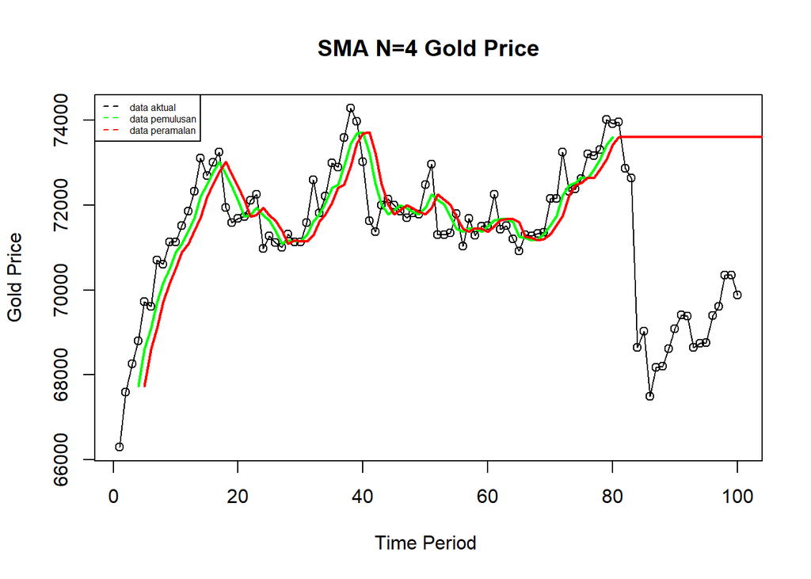

```r
ts.plot(data.ts, xlab="Time Period ", ylab="Gold Price", main= "SMA N=4 Gold Price")
points(data.ts)
lines(data.gab[,2],col="green",lwd=2)
lines(data.gab[,3],col="red",lwd=2)
legend("topleft",c("data aktual","data pemulusan","data peramalan"), lty=8, col=c("black","green","red"), cex=0.5)
```

Selanjutnya perhitungan akurasi dilakukan dengan ukuran akurasi *Sum Squares Error* (SSE), *Mean Square Error* (MSE) dan *Mean Absolute Percentage Error* (MAPE). Perhitungan akurasi dilakukan baik pada data latih maupun pada data uji.

```r
#Menghitung nilai keakuratan data latih
error_train.sma = train_ma.ts-data.ramal[1:length(train_ma.ts)]

SSE_train.sma = sum(error_train.sma[5:length(train_ma.ts)]^2)
MSE_train.sma = mean(error_train.sma[5:length(train_ma.ts)]^2)
MAPE_train.sma = mean(abs((error_train.sma[5:length(train_ma.ts)]/train_ma.ts[5:length(train_ma.ts)])*100))

akurasi_train.sma <- matrix(c(SSE_train.sma, MSE_train.sma, MAPE_train.sma))
row.names(akurasi_train.sma)<- c("SSE", "MSE", "MAPE")
colnames(akurasi_train.sma) <- c("Akurasi m = 4")
akurasi_train.sma
```

```
##      Akurasi m = 4
## SSE   4.524424e+07
## MSE   5.953190e+05
## MAPE  8.438258e-01
```

Dalam hal ini nilai MAPE data latih pada metode pemulusan SMA sekitar 0.84%. Artinya, sangat akurat dalam memprediksi data latih. Kesalahan prediksinya sangat kecil, sehingga model ini dapat dipercaya untuk merepresentasikan pola historis pada data latih.

```r
# Menghitung nilai keakuratan data Test
# Ambil data aktual (baris 81-104, kolom 1)
actual_test <- data.gab[81:104, 1]

# Ambil data ramalan (baris 81-104, kolom 3)
forecast_test <- data.gab[81:104, 3]

# Hitung error
error_test.sma <- actual_test - forecast_test

# Hitung metrik
SSE_test.sma <- sum(error_test.sma^2)
MSE_test.sma <- mean(error_test.sma^2)
MAPE_test.sma <- mean(abs(error_test.sma / actual_test * 100))

akurasi_test.sma <- matrix(c(SSE_test.sma, MSE_test.sma, MAPE_test.sma))
row.names(akurasi_test.sma)<- c("SSE", "MSE", "MAPE")
colnames(akurasi_test.sma) <- c("Akurasi m = 4")
akurasi_test.sma
```

```
##      Akurasi m = 4
## SSE   5.056634e+08
## MSE   2.106931e+07
## MAPE  6.251482e+00
```

Perhitungan akurasi menggunakan data latih menghasilkan nilai MAPE yang kurang dari 10% sehingga nilai akurasi ini dapat dikategorikan sebagai sangat baik.

## Double Moving Average (DMA)

Metode pemulusan Double Moving Average (DMA) pada dasarnya mirip dengan SMA. Namun demikian, metode ini lebih cocok digunakan untuk pola data trend. Proses pemulusan dengan rata rata dalam metode ini dilakukan sebanyak 2 kali.

```r
dma <- SMA(data.sma, n = 4)
At <- 2*data.sma - dma
Bt <- 2/(4-1)*(data.sma - dma)
data.dma<- At+Bt
data.ramal2<- c(NA, data.dma)

t = 1:24
f = c()

for (i in t) {
  f[i] = At[length(At)] + Bt[length(Bt)]*(i)
}

data.gab2 <- cbind(aktual = c(data.ts),
                   pemulusan1 = c(data.sma,rep(NA,24)),
                   pemulusan2 = c(dma, rep(NA,24)),
                   At = c(At, rep(NA,24)),
                   Bt = c(Bt,rep(NA,24)),
                   ramalan = c(data.ramal2, f[-1]))
data.gab2
```

```
##        aktual pemulusan1 pemulusan2       At          Bt  ramalan
##   [1,]  66295         NA         NA       NA          NA       NA
##   [2,]  67592         NA         NA       NA          NA       NA
##   [3,]  68263         NA         NA       NA          NA       NA
##   [4,]  68802   67738.00         NA       NA          NA       NA
##   [5,]  69725   68595.50         NA       NA          NA       NA
##   [6,]  69612   69100.50         NA       NA          NA       NA
##   [7,]  70701   69710.00   68786.00 70634.00  616.000000       NA
##   [8,]  70607   70161.25   69391.81 70930.69  512.958333 71250.00
##   [9,]  71130   70512.50   69871.06 71153.94  427.625000 71443.65
##  [10,]  71127   70891.25   70318.75 71463.75  381.666667 71581.56
##  [11,]  71514   71094.50   70664.88 71524.12  286.416667 71845.42
##  [12,]  71857   71407.00   70976.31 71837.69  287.125000 71810.54
##  [13,]  72329   71706.75   71274.88 72138.62  287.916667 72124.81
##  [14,]  73109   72202.25   71602.62 72801.88  399.750000 72426.54
```

[output cut: 90 more lines]

Hasil pemulusan menggunakan metode DMA divisualisasikan sebagai berikut

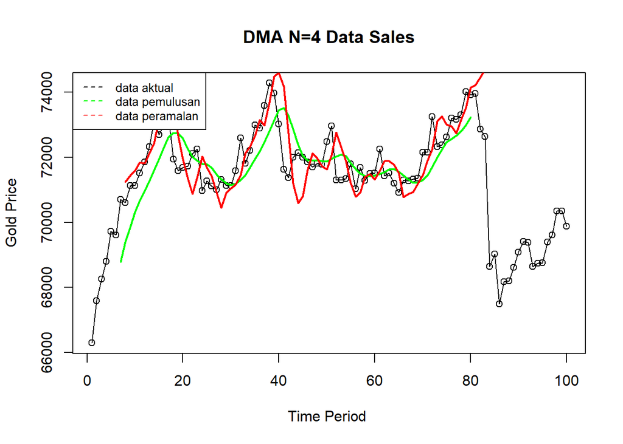

```r
ts.plot(data.ts, xlab="Time Period ", ylab="Gold Price", main= "DMA N=4 Data Sales")
points(data.ts)
lines(data.gab2[,3],col="green",lwd=2)
lines(data.gab2[,6],col="red",lwd=2)
legend("topleft",c("data aktual","data pemulusan","data peramalan"), lty=8, col=c("black","green","red"), cex=0.8)
```

Selanjutnya perhitungan akurasi dilakukan baik pada data latih maupun data uji. Perhitungan akurasi dilakukan dengan ukuran akurasi SSE, MSE dan MAPE.

```r
#Menghitung nilai keakuratan data latih
error_train.dma = train_ma.ts-data.ramal2[1:length(train_ma.ts)]

SSE_train.dma = sum(error_train.dma[8:length(train_ma.ts)]^2)
MSE_train.dma = mean(error_train.dma[8:length(train_ma.ts)]^2)
MAPE_train.dma = mean(abs((error_train.dma[8:length(train_ma.ts)]/train_ma.ts[8:length(train_ma.ts)])*100))

akurasi_train.dma <- matrix(c(SSE_train.dma, MSE_train.dma, MAPE_train.dma))
row.names(akurasi_train.dma)<- c("SSE", "MSE", "MAPE")
colnames(akurasi_train.dma) <- c("Akurasi m = 4")
akurasi_train.dma
```

```
##      Akurasi m = 4
## SSE   4.083869e+07
## MSE   5.594341e+05
## MAPE  8.199618e-01
```

Nilai MAPE sebesar 0,82% menunjukkan bahwa rata-rata kesalahan prediksi model DMA (m=4) terhadap data latih hanya sekitar 0,82% dari nilai aktual. Dengan nilai yang jauh di bawah 10%, akurasi model dapat dikategorikan sangat baik. Hal ini berarti model DMA mampu merepresentasikan pola data latih dengan tingkat kesalahan yang sangat rendah sehingga layak digunakan sebagai dasar peramalan.

```r
# Menghitung nilai keakuratan data uji
# Ambil data aktual (baris 81-104, kolom 1)
actual_test <- data.gab2[81:104, 1]

# Ambil data ramalan (baris 81-104, kolom 3)
forecast_test <- data.gab2[81:104, 6]

# Hitung error
error_test.dma <- actual_test - forecast_test
SSE_test.dma = sum(error_test.dma^2)
MSE_test.dma = mean(error_test.dma^2)
MAPE_test.dma <- mean(abs(error_test.dma / actual_test * 100))

# Menyusun matriks hasil akurasi
akurasi_test.dma <- matrix(c(SSE_test.dma, MSE_test.dma, MAPE_test.dma))
row.names(akurasi_test.dma)<- c("SSE", "MSE", "MAPE")
colnames(akurasi_test.dma) <- c("Akurasi m = 4")
akurasi_test.dma
```

```
##      Akurasi m = 4
## SSE   1.622416e+09
## MSE   6.760066e+07
## MAPE  1.118305e+01
```

MAPE sebesar 11.18% menunjukkan bahwa rata-rata kesalahan prediksi model pada data uji adalah sekitar 11.18% dari nilai aktual. Nilai ini berada pada rentang 10–20%, sehingga model DMA (m=4) dapat dikategorikan memiliki akurasi yang cukup baik. Artinya, meskipun pada data uji model tidak seakurat pada data latih (MAPE jauh lebih kecil), hasil peramalan tetap cukup reliabel dan dapat digunakan sebagai acuan prediksi, meskipun perlu diwaspadai pada kondisi perubahan tren yang tajam.

Pada data latih, metode SMA sama baiknya jika dibandingkan dengan metode DMA. Sedangkan pada data uji, metode SMA lebih baik dibandingkan metode DMA.

# Single Exponential Smoothing & Double Exponential Smoothing

## Pembagian Data

Pembagian data latih dan data uji dilakukan dengan perbandingan 80% data latih dan 20% data uji.

```r
# jumlah baris data
n <- nrow(data)

# hitung batas 80%
n_train <- floor(0.8 * n)

# bagi data
training <- data[1:n_train, ]
testing  <- data[(n_train+1):n, ]

# ubah ke time series
train.ts <- ts(training$Price)
test.ts  <- ts(testing$Price)
```

## Eksplorasi

Eksplorasi dilakukan dengan membuat plot data deret waktu untuk keseluruhan data, data latih, dan data uji.

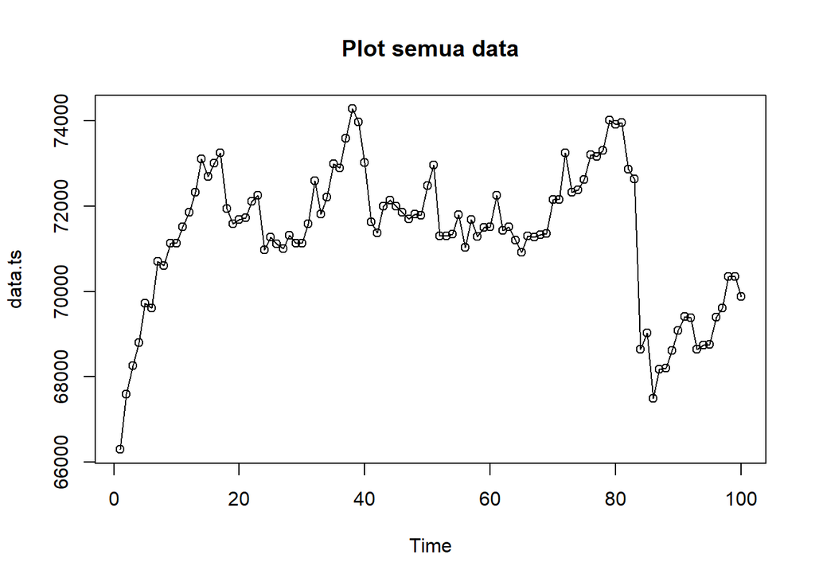

```r
#eksplorasi data
plot(data.ts, col="black",main="Plot semua data")
points(data.ts)
```

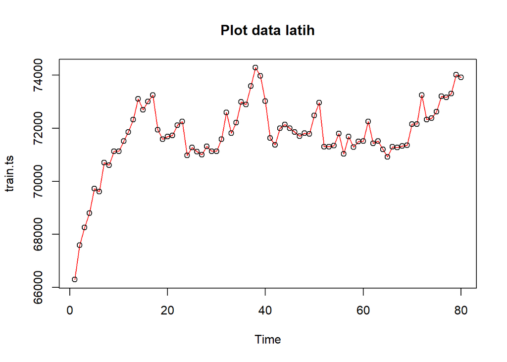

```r
plot(train.ts, col="red",main="Plot data latih")
points(train.ts)
```

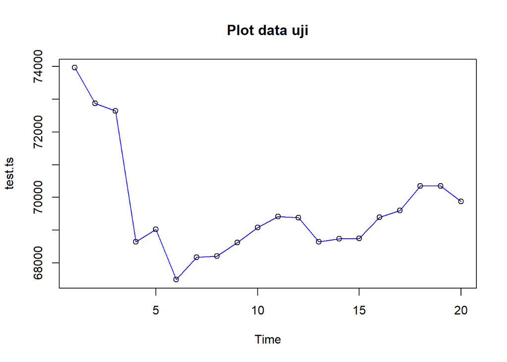

```r
plot(test.ts, col="blue",main="Plot data uji")
points(test.ts)
```

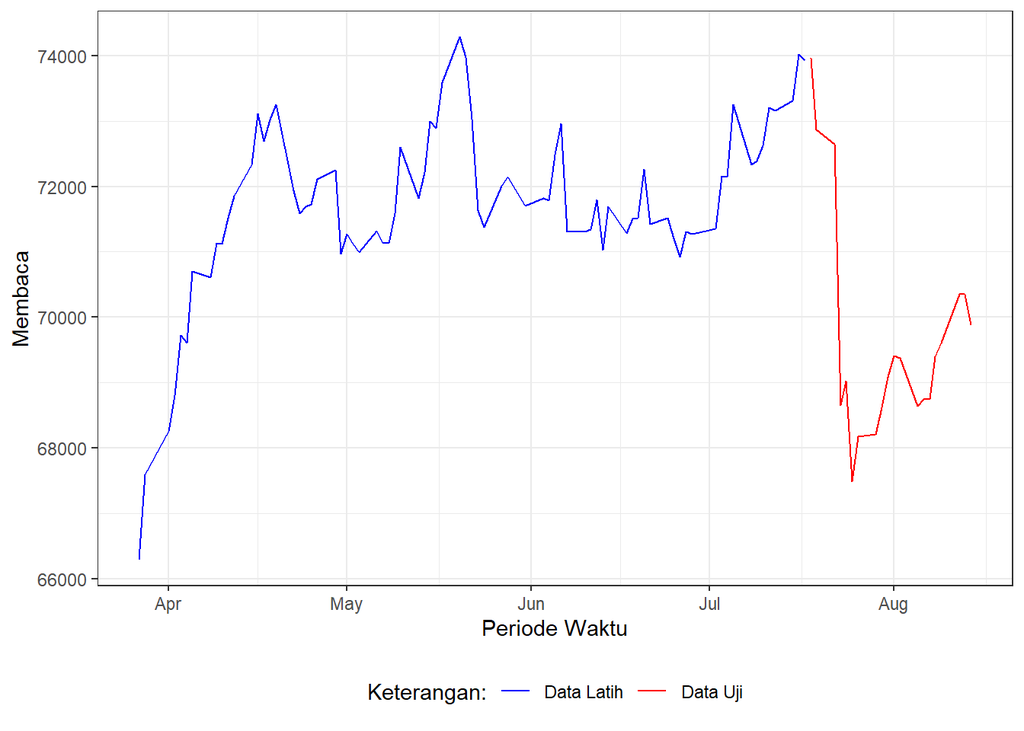

```r
#Eksplorasi dengan GGPLOT
library(ggplot2)
ggplot() +
  geom_line(data = training, aes(x = Date, y = Price, col = "Data Latih")) +
  geom_line(data = testing, aes(x = Date, y = Price, col = "Data Uji")) +
  labs(x = "Periode Waktu", y = "Membaca", color = "Legend") +
  scale_colour_manual(name="Keterangan:", breaks = c("Data Latih", "Data Uji"),
                      values = c("blue", "red")) +
  theme_bw() + theme(legend.position = "bottom",
                     plot.caption = element_text(hjust=0.5, size=12))
```

# Single Exponential Smoothing

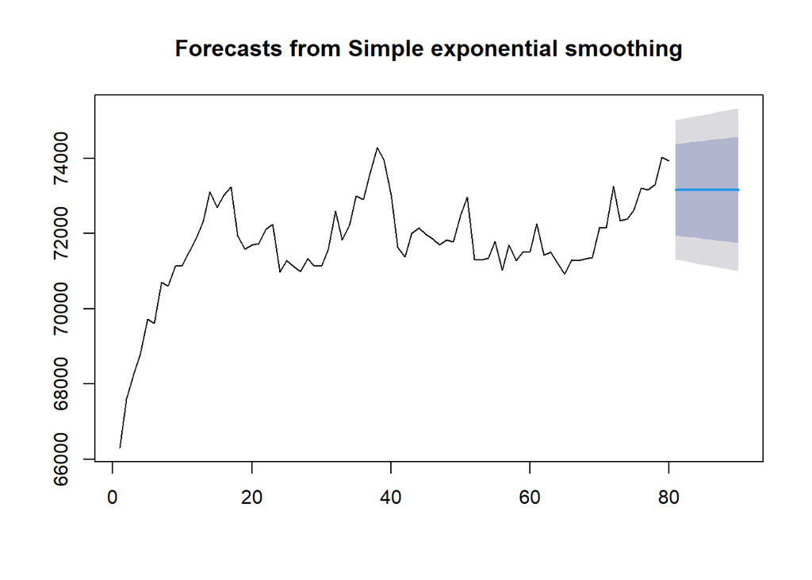

```r
#Cara 1 (fungsi ses)
ses.1 <- ses(train.ts, h = 10, alpha = 0.2)
plot(ses.1)
```

Grafik SES menunjukkan bahwa hasil peramalan (garis biru) cenderung datar mengikuti pola rata-rata data terakhir, sementara area bayangan abu-abu menunjukkan ketidakpastian yang makin besar ke depan. Model ini baik untuk data stabil, tetapi kurang mampu menangkap tren naik atau turun tajam.

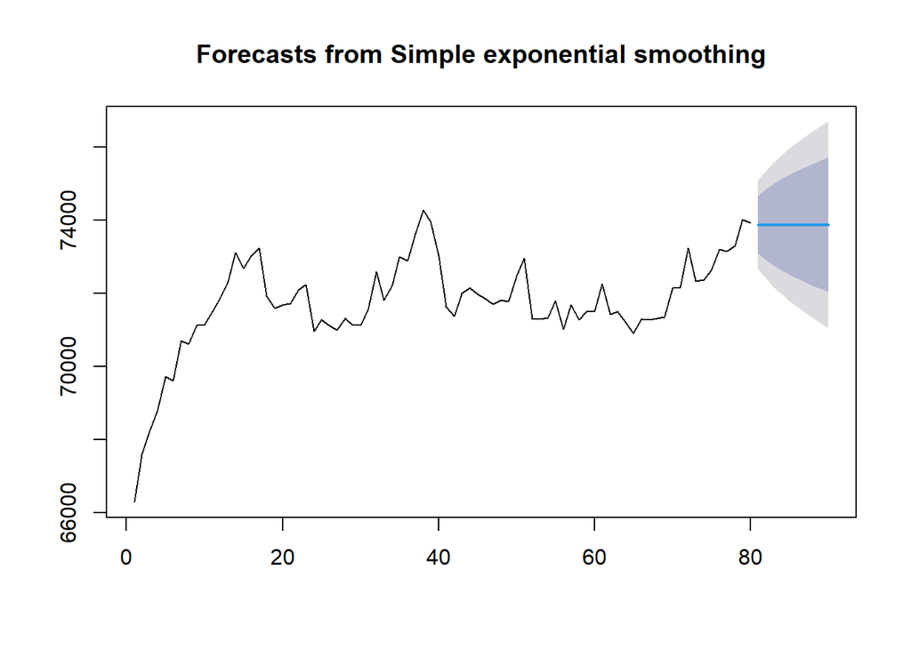

```r
ses.2 <- ses(train.ts, h = 10, alpha = 0.7)
plot(ses.2)
```

Untuk mendapatkan gambar hasil pemulusan pada data latih dengan fungsi `ses()` , perlu digunakan fungsi `autoplot()` dan `autolayer()` dari *library packages* `ggplot2` .

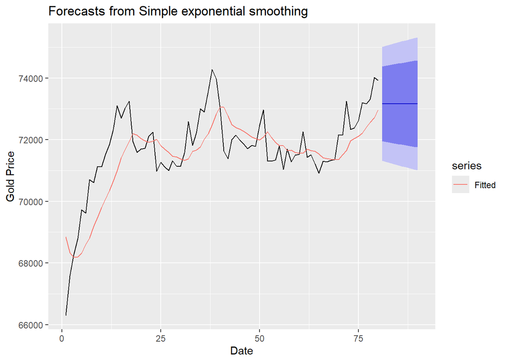

```r
autoplot(ses.1) +
  autolayer(fitted(ses.1), series="Fitted") +
  ylab("Gold Price") + xlab("Date")
```

Model SES ini mampu memberikan peramalan yang relatif stabil dengan mengikuti tren rata-rata data terakhir.

Selanjutnya akan digunakan fungsi `HoltWinters()` dengan nilai inisialisasi parameter dan panjang periode peramalan yang sama dengan fungsi `ses()` .

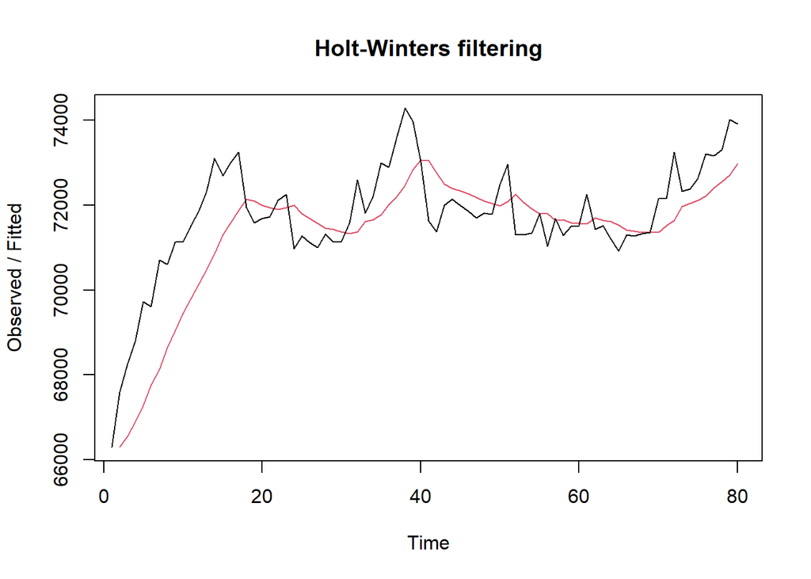

```r
#Cara 2 (fungsi Holtwinter)
ses1<- HoltWinters(train.ts, gamma = FALSE, beta = FALSE, alpha = 0.2)
plot(ses1)
```

```r
#ramalan
ramalan1<- forecast(ses1, h=10)
ramalan1
```

```
##    Point Forecast    Lo 80    Hi 80    Lo 95    Hi 95
## 81       73163.84 71927.09 74400.58 71272.40 75055.28
## 82       73163.84 71902.60 74425.08 71234.94 75092.74
## 83       73163.84 71878.57 74449.10 71198.19 75129.48
## 84       73163.84 71854.99 74472.69 71162.12 75165.55
## 85       73163.84 71831.82 74495.85 71126.69 75200.98
## 86       73163.84 71809.05 74518.62 71091.87 75235.81
## 87       73163.84 71786.65 74541.02 71057.62 75270.06
## 88       73163.84 71764.62 74563.06 71023.92 75303.76
## 89       73163.84 71742.92 74584.75 70990.74 75336.94
## 90       73163.84 71721.55 74606.12 70958.06 75369.62
```

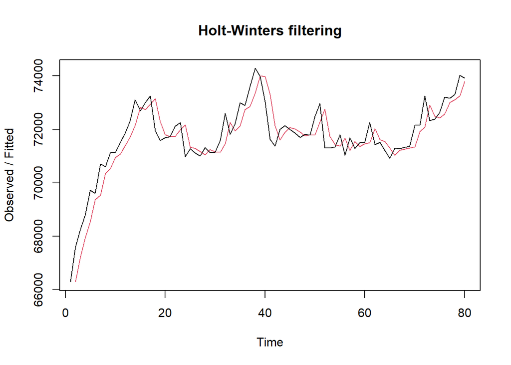

```r
ses2<- HoltWinters(train.ts, gamma = FALSE, beta = FALSE, alpha = 0.7)
plot(ses2)
```

```r
#ramalan
ramalan2<- forecast(ses2, h=10)
ramalan2
```

```
##    Point Forecast    Lo 80    Hi 80    Lo 95    Hi 95
## 81       73884.76 73108.92 74660.59 72698.22 75071.29
## 82       73884.76 72937.73 74831.78 72436.40 75333.11
## 83       73884.76 72793.06 74976.45 72215.15 75554.36
## 84       73884.76 72665.44 75104.08 72019.97 75749.55
## 85       73884.76 72549.96 75219.55 71843.36 75926.15
## 86       73884.76 72443.71 75325.81 71680.86 76088.65
## 87       73884.76 72344.77 75424.75 71529.55 76239.97
## 88       73884.76 72251.81 75517.70 71387.38 76382.13
## 89       73884.76 72163.87 75605.64 71252.89 76516.63
## 90       73884.76 72080.21 75689.30 71124.94 76644.57
```

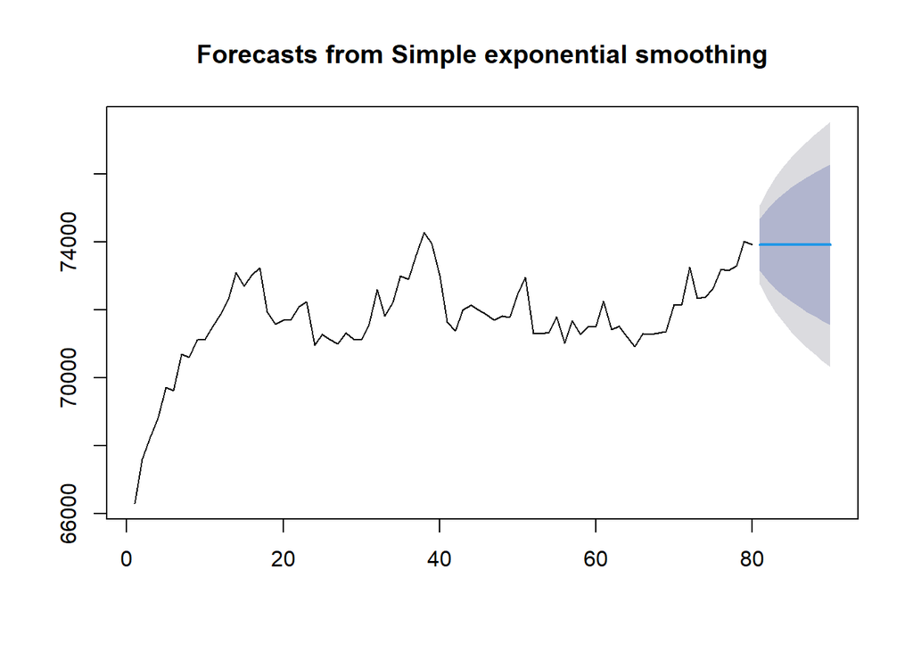

```r
#SES
ses.opt <- ses(train.ts, h = 10, alpha = NULL)
plot(ses.opt)
```

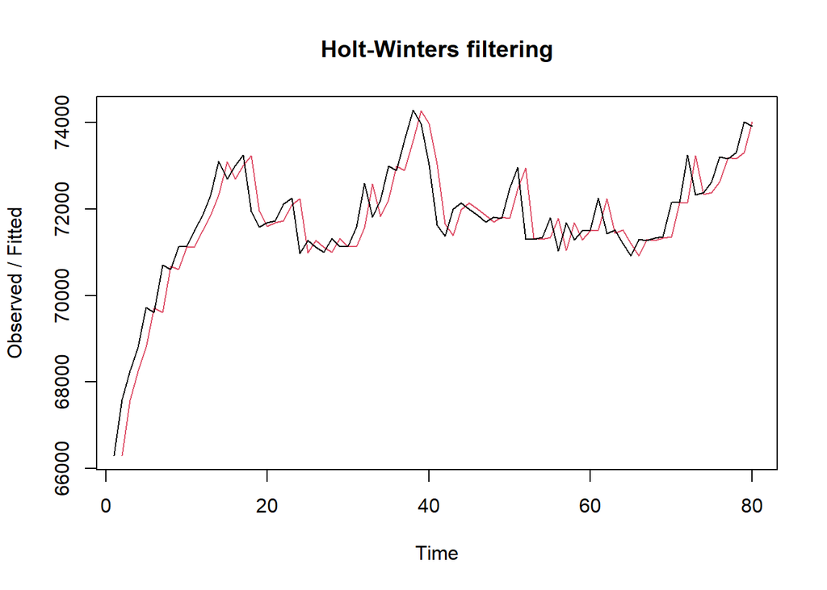

```r
#Lamda Optimum Holt Winter
HWopt<- HoltWinters(train.ts, gamma = FALSE, beta = FALSE,alpha = NULL)
plot(HWopt)
```

```r
#ramalan
ramalanopt<- forecast(HWopt, h=10)
ramalanopt
```

```
##    Point Forecast    Lo 80    Hi 80    Lo 95    Hi 95
## 81       73925.42 73178.09 74672.76 72782.47 75068.37
## 82       73925.42 72876.88 74973.96 72321.82 75529.02
## 83       73925.42 72644.66 75206.19 71966.66 75884.18
## 84       73925.42 72448.51 75402.34 71666.68 76184.17
## 85       73925.42 72275.51 75575.33 71402.10 76448.74
## 86       73925.42 72119.01 75731.83 71162.75 76688.09
## 87       73925.42 71975.03 75875.82 70942.55 76908.30
## 88       73925.42 71840.96 76009.88 70737.52 77113.33
## 89       73925.42 71715.02 76135.83 70544.90 77305.95
## 90       73925.42 71595.87 76254.98 70362.68 77488.17
```

Setelah dilakukan peramalan, akan dilakukan perhitungan keakuratan hasil peramalan. Perhitungan akurasi ini dilakukan baik pada data latih dan data uji.

### Akurasi Data Latih

```r
#Keakuratan Metode
#Pada data training

# SES dengan alpha = 0.2
SSE1<-ses1$SSE
MSE1<-ses1$SSE/length(train.ts)
RMSE1<-sqrt(MSE1)

akurasi1 <- matrix(c(SSE1,MSE1,RMSE1))
row.names(akurasi1)<- c("SSE", "MSE", "RMSE")
colnames(akurasi1) <- c("Akurasi lamda=0.2")
akurasi1
```

```
##      Akurasi lamda=0.2
## SSE       87572021.498
## MSE        1094650.269
## RMSE          1046.255
```

```r
# SES dengan alpha = 0.7
SSE2<-ses2$SSE
MSE2<-ses2$SSE/length(train.ts)
RMSE2<-sqrt(MSE2)

akurasi2 <- matrix(c(SSE2,MSE2,RMSE2))
row.names(akurasi2)<- c("SSE", "MSE", "RMSE")
colnames(akurasi2) <- c("Akurasi lamda=0.7")
akurasi2
```

```
##      Akurasi lamda=0.7
## SSE       3.007464e+07
## MSE       3.759330e+05
## RMSE      6.131338e+02
```

### Akurasi Data Uji

Akurasi data uji dapat dihitung dengan cara yang hampir sama dengan perhitungan akurasi data latih.

```r
# jumlah observasi uji
n_test <- nrow(testing)

# error (ramalan - aktual), samakan panjang dan tipe numeric
e1   <- as.numeric(ramalan1$mean)[1:n_test] - as.numeric(testing$Price)
e2   <- as.numeric(ramalan2$mean)[1:n_test] - as.numeric(testing$Price)
eopt <- as.numeric(ramalanopt$mean)[1:n_test] - as.numeric(testing$Price)

# SSE / MSE / RMSE untuk masing-masing model (abaikan NA)
SSEtesting1  <- sum(e1^2,  na.rm = TRUE)
MSEtesting1  <- mean(e1^2, na.rm = TRUE)
RMSEtesting1 <- sqrt(MSEtesting1)

SSEtesting2  <- sum(e2^2,  na.rm = TRUE)
MSEtesting2  <- mean(e2^2, na.rm = TRUE)
RMSEtesting2 <- sqrt(MSEtesting2)

SSEtestingopt  <- sum(eopt^2,  na.rm = TRUE)
MSEtestingopt  <- mean(eopt^2, na.rm = TRUE)
RMSEtestingopt <- sqrt(MSEtestingopt)

# Tabel ringkas
akurasitesting_SSE <- matrix(c(SSEtesting1, SSEtesting2, SSEtestingopt),
                             nrow = 3,
                             dimnames = list(c("SSE1","SSE2","SSEopt"), "Nilai"))
akurasitesting_MSE <- matrix(c(MSEtesting1, MSEtesting2, MSEtestingopt),
                             nrow = 3,
                             dimnames = list(c("MSE1","MSE2","MSEopt"), "Nilai"))
akurasitesting_RMSE <- matrix(c(RMSEtesting1, RMSEtesting2, RMSEtestingopt),
                              nrow = 3,
                              dimnames = list(c("RMSE1","RMSE2","RMSEopt"), "Nilai"))

akurasitesting_SSE
```

```
##            Nilai
## SSE1   157494939
## SSE2   210149462
## SSEopt 213429303
```

```r
akurasitesting_MSE
```

```
##           Nilai
## MSE1   15749494
## MSE2   21014946
## MSEopt 21342930
```

```r
akurasitesting_RMSE
```

```
##            Nilai
## RMSE1   3968.563
## RMSE2   4584.206
## RMSEopt 4619.841
```

Berdasarkan hasil perhitungan akurasi pada data uji, model SES dengan alpha 0.2 memberikan nilai SSE, MSE, dan RMSE terendah dibandingkan dengan model SES dengan alpha 0.7 dan optimum. Hal ini menunjukkan bahwa model dengan alpha 0.2 memiliki performa terbaik dalam memprediksi data uji, menghasilkan kesalahan prediksi yang paling kecil di antara ketiga model yang diuji.

# *Double Exponential Smoothing* (DES)

Pemulusan dengan metode DES kali ini akan menggunakan fungsi `HoltWinters()` . Jika sebelumnya nilai argumen `beta` dibuat `FALSE` , kali ini argumen tersebut akan diinisialisasi bersamaan dengan nilai `alpha` .

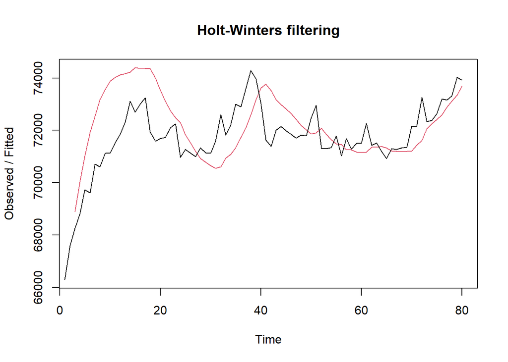

```r
#Lamda=0.2 dan gamma=0.2
des.1<- HoltWinters(train.ts, gamma = FALSE, beta = 0.2, alpha = 0.2)
plot(des.1)
```

```r
#ramalan
ramalandes1<- forecast(des.1, h=10)
ramalandes1
```

```
##    Point Forecast    Lo 80    Hi 80    Lo 95    Hi 95
## 81       73959.72 72456.07 75463.36 71660.09 76259.35
## 82       74182.09 72635.74 75728.43 71817.16 76547.02
## 83       74404.46 72801.82 76007.09 71953.44 76855.47
## 84       74626.83 72953.52 76300.13 72067.72 77185.93
## 85       74849.19 73090.51 76607.88 72159.52 77538.87
## 86       75071.56 73212.87 76930.25 72228.94 77914.18
## 87       75293.93 73321.00 77266.86 72276.60 78311.27
## 88       75516.30 73415.50 77617.10 72303.40 78729.20
## 89       75738.67 73497.08 77980.26 72310.45 79166.89
## 90       75961.04 73566.51 78355.57 72298.92 79623.15
```

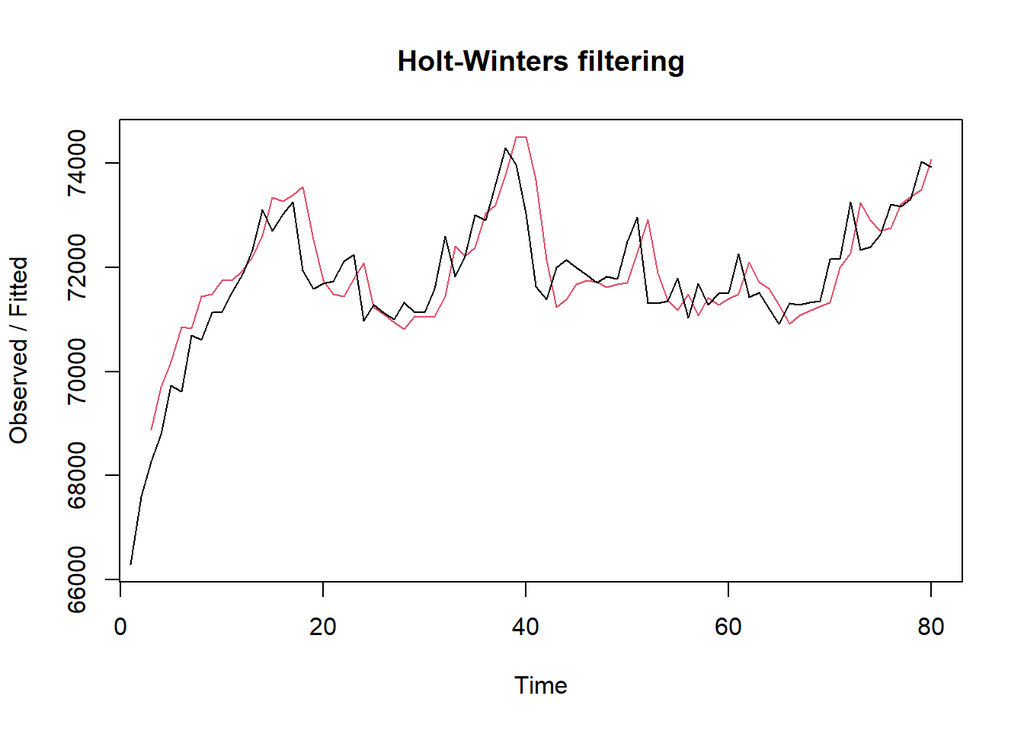

```r
#Lamda=0.6 dan gamma=0.3
des.2<- HoltWinters(train.ts, gamma = FALSE, beta = 0.3, alpha = 0.6)
plot(des.2)
```

```r
#ramalan
ramalandes2<- forecast(des.2, h=10)
ramalandes2
```

```
##    Point Forecast    Lo 80    Hi 80    Lo 95    Hi 95
## 81       74217.40 73398.13 75036.68 72964.43 75470.38
## 82       74451.50 73412.48 75490.53 72862.45 76040.56
## 83       74685.61 73382.47 75988.74 72692.63 76678.58
## 84       74919.71 73316.44 76522.98 72467.72 77371.70
## 85       75153.81 73219.90 77087.72 72196.16 78111.46
## 86       75387.91 73096.58 77679.25 71883.62 78892.21
## 87       75622.01 72949.07 78294.96 71534.10 79709.93
## 88       75856.12 72779.31 78932.93 71150.54 80561.69
## 89       76090.22 72588.78 79591.66 70735.23 81445.21
## 90       76324.32 72378.68 80269.96 70289.98 82358.66
```

Selanjutnya jika ingin membandingkan plot data latih dan data uji adalah sebagai berikut.

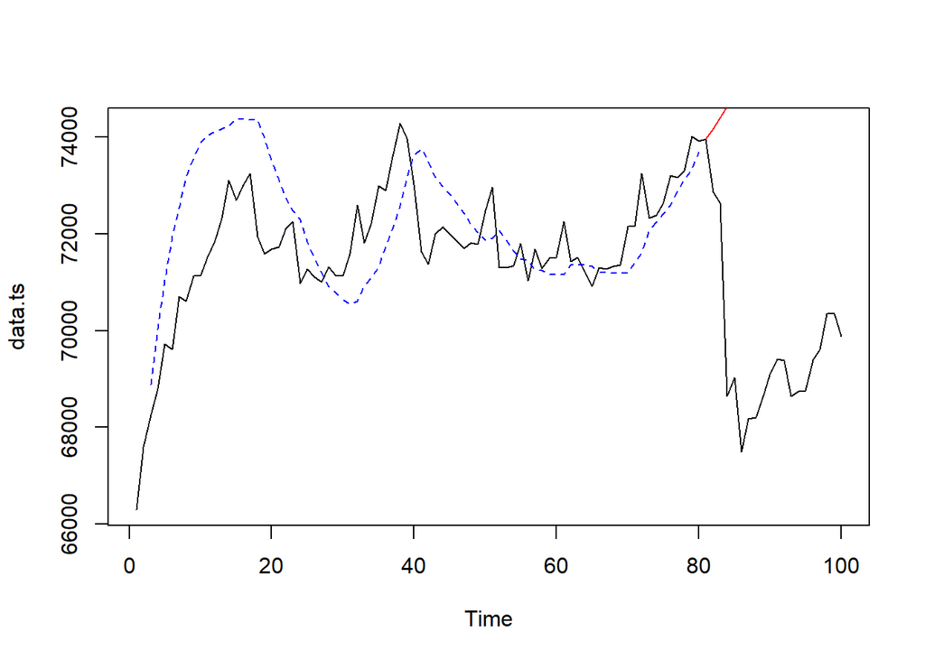

```r
plot(data.ts)
lines(des.1$fitted[,1], lty=2, col="blue")
lines(ramalandes1$mean, col="red")
```

Untuk mendapatkan nilai parameter optimum dari DES, argumen `alpha` dan `beta` dapat dibuat `NULL` seperti berikut.

```r
#Lamda dan gamma optimum
des.opt<- HoltWinters(train.ts, gamma = FALSE)
des.opt
```

```
## Holt-Winters exponential smoothing with trend and without seasonal component.
##
## Call:
## HoltWinters(x = train.ts, gamma = FALSE)
##
## Smoothing parameters:
##  alpha: 0.8812676
##  beta : 0.2242322
##  gamma: FALSE
##
## Coefficients:
##         [,1]
## a 73959.6060
## b   205.5445
```

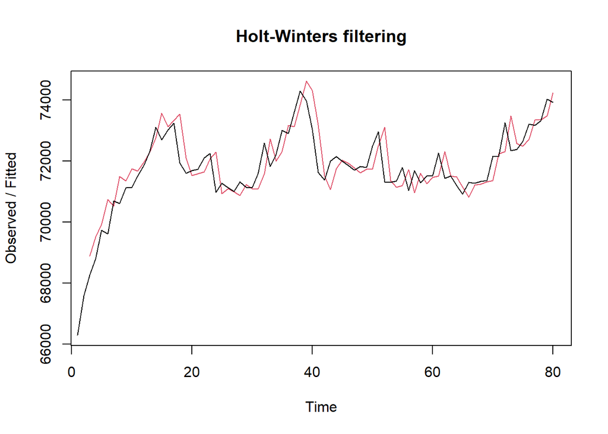

```r
plot(des.opt)
```

```r
#ramalan
ramalandesopt<- forecast(des.opt, h=10)
ramalandesopt
```

```
##    Point Forecast    Lo 80    Hi 80    Lo 95    Hi 95
## 81       74165.15 73381.32 74948.99 72966.38 75363.92
## 82       74370.69 73217.64 75523.75 72607.25 76134.14
## 83       74576.24 73049.59 76102.89 72241.44 76911.04
## 84       74781.78 72867.18 76696.39 71853.65 77709.92
## 85       74987.33 72667.26 77307.39 71439.10 78535.56
## 86       75192.87 72448.86 77936.88 70996.27 79389.48
## 87       75398.42 72211.82 78585.01 70524.94 80271.90
## 88       75603.96 71956.35 79251.58 70025.42 81182.51
## 89       75809.51 71682.81 79936.20 69498.27 82120.75
## 90       76015.05 71391.63 80638.47 68944.14 83085.96
```

Selanjutnya akan dilakukan perhitungan akurasi pada data latih maupun data uji dengan ukuran akurasi SSE, MSE dan MAPE.

### Akurasi Data Latih

```r
#Akurasi Data Training
ssedes.train1<-des.1$SSE
msedes.train1<-ssedes.train1/length(train.ts)
sisaandes1<-ramalandes1$residuals
head(sisaandes1)
```

```
## Time Series:
## Start = 1
## End = 6
## Frequency = 1
## [1]        NA        NA  -626.000 -1233.760 -1286.618 -2313.439
```

```r
mapedes.train1 <- sum(abs(sisaandes1[3:length(train.ts)]/train.ts[3:length(train.ts)])
                      *100)/length(train.ts)

akurasides.1 <- matrix(c(ssedes.train1,msedes.train1,mapedes.train1))
row.names(akurasides.1)<- c("SSE", "MSE", "MAPE")
colnames(akurasides.1) <- c("Akurasi lamda=0.2 dan gamma=0.2")
akurasides.1
```

```
##      Akurasi lamda=0.2 dan gamma=0.2
## SSE                     1.152542e+08
## MSE                     1.440678e+06
## MAPE                    1.302884e+00
```

```r
ssedes.train2<-des.2$SSE
msedes.train2<-ssedes.train2/length(train.ts)
sisaandes2<-ramalandes2$residuals
head(sisaandes2)
```

```
## Time Series:
## Start = 1
## End = 6
## Frequency = 1
## [1]         NA         NA  -626.0000  -895.7200  -458.3784 -1236.9336
```

```r
mapedes.train2 <- sum(abs(sisaandes2[3:length(train.ts)]/train.ts[3:length(train.ts)])
                      *100)/length(train.ts)

akurasides.2 <- matrix(c(ssedes.train2,msedes.train2,mapedes.train2))
row.names(akurasides.2)<- c("SSE", "MSE", "MAPE")
colnames(akurasides.2) <- c("Akurasi lamda=0.6 dan gamma=0.3")
akurasides.2
```

```
##      Akurasi lamda=0.6 dan gamma=0.3
## SSE                     3.191568e+07
## MSE                     3.989460e+05
## MAPE                    6.579157e-01
```

Hasil akurasi dari data latih didapatkan skenario 2 dengan lamda=0.6 dan gamma=0.3 memiliki hasil yang lebih baik. Namun untuk kedua skenario dapat dikategorikan peramalan sangat baik berdasarkan nilai MAPE-nya.

### Akurasi Data Uji

```r
selisihdes1<-as.numeric(ramalandes1$mean) - as.numeric(testing$Price)
selisihdes1
```

```
##  [1]   -5.280398 1310.088371 1763.457140 5978.825909 5821.194678 7580.563447
##  [7] 7120.932216 7310.300984 7121.669753 6878.038522 4547.719602 4801.088371
## [13] 5763.457140 5884.825909 6097.194678 5675.563447 5689.932216 5162.300984
## [19] 5382.669753 6087.038522
```

```r
SSEtestingdes1<-sum(selisihdes1^2)
MSEtestingdes1<-SSEtestingdes1/length(testing$Price)
MAPEtestingdes1<-sum(abs(selisihdes1/testing$Price)*100)/length(testing$Price)
```

```r
selisihdes2<-as.numeric(ramalandes2$mean) - as.numeric(testing$Price)
selisihdes2
```

```
##  [1]  252.4028 1579.5047 2044.6067 6271.7086 6125.8105 7896.9125 7449.0144
##  [8] 7650.1163 7473.2183 7241.3202 4805.4028 5070.5047 6044.6067 6177.7086
## [15] 6401.8105 5991.9125 6018.0144 5502.1163 5734.2183 6450.3202
```

```r
SSEtestingdes2<-sum(selisihdes2^2)
MSEtestingdes2<-SSEtestingdes2/length(testing$Price)
MAPEtestingdes2<-sum(abs(selisihdes2/testing$Price)*100)/length(testing$Price)
```

```r
selisihdesopt<-as.numeric(ramalandesopt$mean)-as.numeric(testing$Price)
selisihdesopt
```

```
##  [1]  200.1505 1498.6950 1935.2394 6133.7839 5959.3284 7701.8728 7225.4173
##  [8] 7397.9618 7192.5063 6932.0507 4753.1505 4989.6950 5935.2394 6039.7839
## [15] 6235.3284 5796.8728 5794.4173 5249.9618 5453.5063 6141.0507
```

```r
SSEtestingdesopt<-sum(selisihdesopt^2)
MSEtestingdesopt<-SSEtestingdesopt/length(testing$Price)
MAPEtestingdesopt<-sum(abs(selisihdesopt/testing$Price)*100)/length(testing$Price)
```

```r
akurasitestingdes <-
  matrix(c(SSEtestingdes1,MSEtestingdes1,MAPEtestingdes1,SSEtestingdes2,MSEtestingdes2,
           MAPEtestingdes2,SSEtestingdesopt,MSEtestingdesopt,MAPEtestingdesopt),
         nrow=3,ncol=3)
row.names(akurasitestingdes)<- c("SSE", "MSE", "MAPE")
colnames(akurasitestingdes) <- c("des ske1","des ske2","des opt")
akurasitestingdes
```

```
##          des ske1     des ske2      des opt
## SSE  6.401160e+08 7.096250e+08 6.654782e+08
## MSE  3.200580e+07 3.548125e+07 3.327391e+07
## MAPE 7.672784e+00 8.118447e+00 7.857756e+00
```

### Perbandingan SES dan DES

```r
MSEfull <-
  matrix(c(MSEtesting1,MSEtesting2,MSEtestingopt,MSEtestingdes1,MSEtestingdes2,
           MSEtestingdesopt),nrow=3,ncol=2)
row.names(MSEfull)<- c("ske 1", "ske 2", "ske opt")
colnames(MSEfull) <- c("ses","des")
MSEfull
```

```
##              ses      des
## ske 1   15749494 32005800
## ske 2   21014946 35481250
## ske opt 21342930 33273911
```

# Kesimpulan

Berikut kesimpulan singkatnya kenapa SES lebih baik dibanding DES pada data ini: 1. Tren data tidak konsisten/stabil → DES sulit menangkap pola. 2. Parameter DES (λ, γ) belum optimal → bisa menyebabkan error lebih besar. 3. Horizon ramalan pendek → tren kurang berpengaruh, SES lebih stabil. 4. Data lebih didominasi fluktuasi (noise) → model sederhana (SES) justru lebih akurat.